# Compiling and visualizing results

**Goals**

I have exported the results for each main response variable to rds files, but now I need prepare results for reporting and interpretation.

Specific goals:

1. Create summary tables for each model into an easily exportable table.
2. Calculate contrasts and confidence intervals, and organize them into a table. I want to be able to say: “the pre-to-post change in treatment replicates was X times larger (or smaller) than the pre-to-post change in control replicates (95% CI: X - X times) .
3. Make plots of contrasts in #2. These will be plots for main text.
4. Make plots of estimated marginal means for control/treatment and pre/post (interaction plots)

```r
source("../../code/helper_functions/Modeling_helper_functions.R")
source("../../code/helper_functions/Plotting_helper_functions.R")
source("../../code/helper_functions/Extract_data_from_safely_and_quietly_lists.R")
source("../../code/helper_functions/Calculate_basic_summary_stats.R")
```

## Step 1: Get results (rds files)

```r
captures <- readRDS("../../results/statistical_analysis/rds_files/Capture_results.rds")

telemetry <- readRDS("../../results/statistical_analysis/rds_files/Telemetry_results.rds")

cameras <- readRDS("../../results/statistical_analysis/rds_files/Camera_results.rds") %>%
  mutate(plant_species = factor(plant_species, levels = c("MARA", "PAV-ROJ-AMA", "CEPO", "TUBO-AMA", "HAPA", "PALU", "RABO", "BOCA-ROJA", "COSTBAR"), ordered = TRUE)) %>%
  arrange(plant_species)

pollen_tubes <- readRDS("../../results/statistical_analysis/rds_files/Pollen_tube_results.rds") %>%
  mutate(subanalysis = factor(subanalysis, levels = c("HETO", "HAPA"), ordered = TRUE)) %>%
  arrange(subanalysis)

body_mass <- readRDS("../../results/statistical_analysis/rds_files/Body_mass_results.rds")

results <- captures %>%
  bind_rows(telemetry) %>%
  bind_rows(cameras) %>%
  bind_rows(pollen_tubes) %>%
  bind_rows(body_mass) %>%
  select(-model_number) %>% #Model number within a given analysis. Replace with unique #
  mutate(model_number = 1:length(yvar)) %>%
  select(model_number, everything())

#How many total models?
length(results$model_number)
```

```
## [1] 49
```

```r
#What non-Heliconia species were analyzed? Plant species scientific names for plots
nonheto_species <- read.csv("../../data/export/supp_tables/Non-Heliconia_camera_species_list.csv") %>%
  filter(plant_species %in% results$plant_species) %>%
  select(plant_species, plant_scientific_name, num_replicates)
```

## Step 2: Create model summaries, calculate confidence intervals, and tidy results into dataframe for export

```r
#Columns to keep when extract the results
col_names <- c("model_number", "analysis", "subanalysis", "model_type", "bird_group", "plant_species", "yvar")

#Extract model summaries
results_tidy <- results %>%
  select(append(col_names, "summary_tidy")) %>%
  unnest(c(summary_tidy))

#Extract confidence intervals
results_confint <- results %>%
  select(append(col_names, "confint_wald")) %>%
  mutate(confint_df = map(confint_wald, as.data.frame)) %>% #CI as dataframe
  mutate(confint_df = map(confint_df, ~tibble::rownames_to_column(., var = "term"))) %>%
  unnest(cols = confint_df) %>%
  rename(lowerCI = "2.5 %", upperCI = "97.5 %") %>%
  select(-confint_wald, -Estimate)

#Back-transform (exponentiate) coefficients and confidence intervals to data scale from model scale
results_tidy_confint <- results_tidy %>%
  left_join(results_confint) %>%
  mutate_at(vars(estimate, lowerCI, upperCI), .funs = list(exp = ~ifelse(effect == "fixed", exp(.), NA))) %>%
  mutate_at(vars(estimate, std.error, statistic, lowerCI, upperCI, estimate_exp, lowerCI_exp, upperCI_exp), ~round(., digits = 2)) %>%
  mutate(pvalue_round = format.pval(pv = round(p.value, 3), digits = 3, nsmall = 3, eps = 0.001)) %>%
  select(model_number:term, estimate, lowerCI, upperCI, statistic, pvalue_round, pvalue = p.value, std_error = std.error, everything())
```

## Step 3: Calculate estimated marginal means for categorical models

I will calculate estimated marginal means to visualize and help interpret results. However, since I am using mixed models, I need to adjust the estimated values for the random effects (i.e., ‘bias adjustment’: https://cran.r-project.org/web/packages/emmeans/vignettes/transformations.html#bias-adj). The adjustment is implemented using the ‘bias.adjust’ and ‘sigma’ arguments in emmeans, where sigma is calculated from the random effect standard deviations (i.e., sqrt(SD1^2 + SD2^2)).

Calculate sigma

```r
#In general, you should always use the VarCorr() results to obtain sigma when you have a mixed model.
#Example in the emmeans vignette manually extracts the elements of VarCorr(), e.g., VarCorr(model)$cond$`bird_id:year_patch:patch`[[1]] - but that approach seems unwieldy since I already have the SDs in a tidy format! Will just summarize there.
bias_adjust_values <- results_tidy_confint %>%
  filter(effect == "ran_pars") %>%
  mutate(estimate2 = estimate^2) %>%
  group_by(model_number, analysis, subanalysis, bird_group, plant_species, yvar) %>%
  summarise(sum_estimate2 = sum(estimate2)) %>%
  ungroup() %>%
  mutate(sigma = sqrt(sum_estimate2))
```

```r
#For the means and contrasts, will only look at categorical models
#Also need to add sigma for bias adjustment
results_categorical <- results %>%
  filter(model_type == "categorical") %>%
  left_join(bias_adjust_values)
```

```r
#Models for cameras have offset; I want to calculate the number of visits per 12-hour day
emmeans_cameras <- results_categorical %>%
  filter(analysis == "camera_HETO" | analysis == "camera_non-HETO" | analysis == "camera_non-HETO_separate") %>%
  filter(is.na(plant_species) | plant_species != "RABO") %>% #RABO model was weird, fit better with hours as covariate instead of offset
  mutate(emmeans = pmap(list(model, sigma), ~emmeans(..1, specs = ~exp_phase:control_treatment, type = "response", offset = log(12), bias.adjust = TRUE, sigma = ..2))) %>%
  mutate(emmeans = map(emmeans, as.data.frame)) %>%
  arrange(model_number)

#Check to make sure that offset is being applied correctly; looks like log(offset) is needed for emmeans::emmeans()
emmeans_cameras$emmeans[[1]]
```

```
##  exp_phase control_treatment  response        SE df  lower.CL upper.CL
##  pre       control           0.4357762 0.2794444 40 0.1192355 1.592654
##  post      control           0.6924189 0.4336281 40 0.1952910 2.455024
##  pre       treatment         2.7083553 1.2370072 40 1.0759896 6.817155
##  post      treatment         1.9880563 0.8956521 40 0.7998186 4.941580
##
## Confidence level used: 0.95
## Intervals are back-transformed from the log scale
## Bias adjustment applied based on sigma = 1.37
```

```r
#Models for recaps do not have the interaction between treatment and exp_phase
emmeans_recaps <- results_categorical %>%
  filter(subanalysis == "recaptures") %>%
  mutate(emmeans = pmap(list(model, sigma), ~emmeans(..1, specs = ~control_treatment, type = "response", bias.adjust = TRUE, sigma = ..2))) %>%
  mutate(emmeans = map(emmeans, as.data.frame))

#Other models
emmeans_other <- results_categorical %>%
  filter(!(model_number %in% emmeans_cameras$model_number) & !(model_number %in% emmeans_recaps$model_number)) %>%
  mutate(emmeans = pmap(list(model, sigma), ~emmeans(..1, specs = ~exp_phase:control_treatment, type = "response", bias.adjust = TRUE, sigma = ..2))) %>%
  mutate(emmeans = map(emmeans, as.data.frame))

#As data frame
emmeans_df <- emmeans_cameras %>%
  bind_rows(emmeans_recaps) %>%
  bind_rows(emmeans_other) %>%
  arrange(model_number) %>%
  select(append(col_names, "emmeans")) %>%
  unnest(emmeans) %>%
  mutate_if(is.numeric, ~round(., digits = 2)) %>%
  select(-SE, -df) %>%
  unite("estimate", c("rate", "prob", "response", "emmean"), na.rm = TRUE) %>%
  mutate(across(c(estimate, lower.CL, upper.CL), as.numeric))

#Will need to filter these data for each plot
```

## Step 4: Calculate relevant contrasts

Contrasts will also help with results interpretation, especially for models that include an interaction term. For models with an interaction term, I can calculate two different types of contrasts:

1. pre-to-post change in treatment replicates *AND* pre-to-post change in control replicates (calculated separately)
2. pre-to-post change in treatment replicates *RELATIVE TO* pre-to-post change in control replicates. This is the contrast reflecting the treatment:period interaction term and is a ‘contrast of a contrast’.

When interpreting the contrasts, I also need to think about the link function of the model.

**Models with log link**

- Captures (Poisson; # hummingbirds captured)
- Cameras (Poisson/negative binomial; # hummingbird visits)

The default back-transformed contrasts provide *ratios*. These are easy enough to interpret.

**Models with logit link**

- Telemetry (betabinomial; proportion of time spent in focal area)
- Pollen tubes (binomial; proportion of styles with at least one pollen tube)
- Recaptures (binomial; proportion of birds recaptured during ‘post’ period)

The default back-transformed contrasts provide *odds ratios*. They are OK to interpret, but in this case I want to eventually have contrasts for multiple analyses on the same plot. It might be confusing to mix ratios and odds ratios; ideally I would just have ratios.

The solution to this problem is to calculate [“risk ratios”, aka “proportion ratios”](https://github.com/rvlenth/emmeans/issues/48) on the data scale by using emmeans::regrid() and then supplying the ‘type=“response”’ as an argument to confint() or summary().

**Models that don’t use a link function**

- Body mass (Gaussian; body mass relative to structural size, i.e., wing length)

```r
#emmeans::confint() gives confidence intervals around contrast
#emmeans::summary() gives p-value for contrast

#CAMERAS AND CAPTURES (log link)
contrasts_cameras_captures <- results_categorical %>%
  filter(analysis == "camera_HETO" | analysis == "camera_non-HETO" | analysis == "camera_non-HETO_separate" | (analysis == "captures" & subanalysis == "captures")) %>%
  mutate(emm = map(model, ~emmeans(., specs = ~exp_phase:control_treatment))) %>%
  mutate(contrast = map(emm, ~as.data.frame(confint(contrast(., method = "revpairwise", by = c("control_treatment")), type = "response")))) %>%
  mutate(contrast_of_contrast = map(emm, ~as.data.frame(confint(contrast(., interaction = "revpairwise"), type = "response"))))

#TELEMETRY AND POLLEN TUBES (logit link)
contrasts_telemetry_pollen_tubes <- results_categorical %>%
  filter(analysis == "telemetry" | analysis == "pollen_tubes") %>%
  mutate(emm = map(model, ~emmeans(., specs = ~exp_phase:control_treatment))) %>%
  mutate(emm_regrid = map(emm, ~regrid(., transform = "log"))) %>%
  mutate(contrast = map(emm_regrid, ~as.data.frame(confint(contrast(., interaction = "revpairwise", by = c("control_treatment")), type = "response")))) %>%
  mutate(contrast_of_contrast = map(emm_regrid, ~as.data.frame(confint(contrast(., interaction = "revpairwise"), type = "response"))))

#RECAPTURES (logit link, but don't have the treatment x period interaction)
contrasts_recaps <- results_categorical %>%
  filter(subanalysis == "recaptures") %>%
  mutate(emm = map(model, ~emmeans(., specs = ~control_treatment))) %>%
  mutate(emm_regrid = map(emm, ~regrid(., transform = "log"))) %>%
  mutate(contrast = map(emm_regrid, ~as.data.frame(confint(contrast(., interaction = "revpairwise"), type = "response"))))

#BODY MASS (Gaussian, so change will be relative to ZERO, not 1)
contrasts_body_mass <- results_categorical %>%
  filter(subanalysis == "body_mass") %>%
  mutate(emm = map(model, ~emmeans(., specs = ~exp_phase:control_treatment))) %>%
  mutate(contrast = map(emm, ~as.data.frame(confint(contrast(., by = c("control_treatment"), method = "revpairwise"))))) %>%
  mutate(contrast_of_contrast = map(emm, ~as.data.frame(confint(contrast(., interaction = c("revpairwise", "revpairwise")))))) %>%
  mutate(contrast_of_contrast = map(contrast_of_contrast, ~rename(., ratio = estimate))) #Rename column to match other analyses, but note that it's not actually a ratio!

contrasts_body_mass$contrast
```

```
## [[1]]
## control_treatment = control:
##  contrast      estimate          SE df     lower.CL   upper.CL
##  post - pre 0.006812232 0.009730411 54 -0.012696068 0.02632053
##
## control_treatment = treatment:
##  contrast      estimate          SE df     lower.CL   upper.CL
##  post - pre 0.013118559 0.008508998 54 -0.003940954 0.03017807
##
## Confidence level used: 0.95
##
## [[2]]
## control_treatment = control:
##  contrast     estimate        SE df     lower.CL   upper.CL
##  post - pre 0.02112327 0.0130866 26 -0.005776622 0.04802316
##
## control_treatment = treatment:
##  contrast     estimate        SE df     lower.CL   upper.CL
##  post - pre 0.02520240 0.0130866 26 -0.001697495 0.05210229
##
## Confidence level used: 0.95
```

```r
contrasts_body_mass$contrast_of_contrast
```

```
## [[1]]
##  exp_phase_revpairwise control_treatment_revpairwise       ratio        SE df
##  post - pre            treatment - control           0.006306327 0.0129261 54
##     lower.CL   upper.CL
##  -0.01960893 0.03222159
##
## Confidence level used: 0.95
##
## [[2]]
##  exp_phase_revpairwise control_treatment_revpairwise       ratio         SE df
##  post - pre            treatment - control           0.004079128 0.01850725 26
##     lower.CL   upper.CL
##  -0.03396306 0.04212132
##
## Confidence level used: 0.95
```

```r
#Combine
#Pre-to-post change, control and treatment replicates separately
contrasts <- contrasts_cameras_captures %>%
  bind_rows(contrasts_telemetry_pollen_tubes) %>%
  bind_rows(contrasts_body_mass)

#Contrasts reflecting the coefficient of interest (interaction term for all analyses except recaptures)
contrasts_of_contrasts <- contrasts_recaps %>%
  rename(contrast_of_contrast = contrast) %>%
  bind_rows(contrasts_cameras_captures) %>%
  bind_rows(contrasts_telemetry_pollen_tubes) %>%
  bind_rows(contrasts_body_mass)
```

Extract contrast results

```r
#Contrasts for control and treatment replicates separately
contrasts_df <- contrasts %>%
  select(append(col_names, "contrast")) %>%
  unnest(contrast) %>%
  arrange(model_number) %>%
  mutate_if(is.numeric, ~round(., digits = 2)) %>%
  mutate(contrast = ifelse(is.na(contrast), as.character(exp_phase_revpairwise), as.character(contrast))) %>%
  select(-exp_phase_revpairwise) %>%
  select(model_number:contrast, control_treatment, ratio, lower.CL, upper.CL, everything())

#Contrasts for treatment effect; for models with treatment x period interaction, this is the contrast representing that interaction term (contrast of contrasts)
contrasts_of_contrasts_df <- contrasts_of_contrasts %>%
  select(append(col_names, "contrast_of_contrast")) %>%
  unnest(contrast_of_contrast) %>%
  arrange(model_number) %>%
  mutate_if(is.numeric, ~signif(., digits = 2)) %>%
  select(model_number:starts_with("control_treatment"), starts_with("exp_phase"), ratio, lower.CL, upper.CL, everything())
```

Combine all model results into summary table(s) for Supporting information

```r
#This table will include the relevant contrast for the experimental effect alongside the p-value associated with the interaction term
results_supp_table <- results_tidy_confint %>%
  filter(term == "control_treatmenttreatment:exp_phasepost" | term == "log_calories_removed_per_ha:exp_phasepost" |
           (subanalysis == "recaptures" & (term == "control_treatmenttreatment" | term == "log_calories_removed_per_ha"))) %>%
  select(model_type, analysis, subanalysis, bird_group, plant_species, yvar, z = statistic, p = pvalue_round) %>%
  pivot_wider(names_from = model_type, names_glue = "{model_type}_{.value}", values_from = c(z, p)) %>%
  left_join(contrasts_of_contrasts_df) %>%
  select(analysis:yvar, ratio, lower.CL, upper.CL, starts_with("categorical"), starts_with("quantitative")) %>%

  #For Supp info, may need to split into two tables: primary response variables + additional response variables
  mutate(primary_vs_additional = ifelse(subanalysis == "recaptures" | subanalysis == "marked_birds" | subanalysis == "body_mass", "additional", "primary")) %>%
  mutate(analysis = factor(analysis, levels = c("captures", "telemetry", "camera_HETO", "camera_non-HETO", "camera_non-HETO_separate", "pollen_tubes"))) %>%
  arrange(desc(primary_vs_additional), analysis)
```

Create summary of sample sizes for Supporting information

```r
#Extract number of control and treatment replicates for each dataset
#Will be the same for both model types (categorical and quantitative), so only need one
sample_size <- results_categorical %>%
  select(append(append(col_names, "num_obs"), "num_reps")) %>%
  unnest(cols = num_reps) %>%
  mutate(num_obs = unlist(num_obs)) %>%
  pivot_wider(names_from = control_treatment, values_from = n) %>%

  #For Supp info, may need to split into two tables: primary response variables + additional response variables
  mutate(primary_vs_additional = ifelse(subanalysis == "recaptures" | subanalysis == "marked_birds" | subanalysis == "body_mass", "additional", "primary")) %>%
  mutate(analysis = factor(analysis, levels = c("captures", "telemetry", "camera_HETO", "camera_non-HETO", "camera_non-HETO_separate", "pollen_tubes"))) %>%
  arrange(desc(primary_vs_additional), analysis)
```

## Step 5: Plot results

There are two ways that I like to visualize the interaction term of interest

1. Interaction plots, with estimated marginal means for control/treatment and pre/post (pre and post values connected by lines)
2. Contrast plots, with contrast reflecting the interaction term and its associated confidence intervals

**Prepare to export plots with proper sizing**

```r
#Recommended figure widths from journal (pixels @ 300 dpi)
column1x <- 945 #single-column
column1.5x <- 1476 #1.5 columns
column2x <- 1961 #double column

#Sizes for plot elements
size = 6.5
label_size = size
title_size = size * 1.15
shape_size = 1
line_width = 0.25

path_name <- c("../../results/statistical_analysis/figures")
```

**Make interaction plots**

```r
#Calculate max values for each response variable
#If want to have common axis scaling across variables that will be in same plot, can group again and take max across those variables
max_values <- emmeans_df %>%
  group_by(analysis, subanalysis, plant_species) %>%
  summarise(ymax = round(max(upper.CL) + 0.5, 0)) %>%
  ungroup() %>%
  mutate(ymin = 0) %>%
  mutate(ybreak = 1) %>%
  mutate(yaccuracy = 1)

#Make a bunch of interaction plots
#Adjust axis limits and breaks as needed (NOTE: body mass plot was kind of complicated so tailored it in function)
#Filter emmeans data to each analysis
interaction_plots <- results_categorical %>%
  filter(subanalysis != "recaptures") %>%
  left_join(max_values) %>%
  mutate(ymax = ifelse(analysis == "camera_non-HETO" & subanalysis == "all_birds" & bird_group == "greh_visa", 3, ymax)) %>%
  mutate(ymax = ifelse(analysis == "telemetry", 0.6, ymax)) %>%
  mutate(ybreak = ifelse(analysis == "camera_HETO" & subanalysis == "all_birds", 3, ybreak)) %>%
  mutate(ybreak = ifelse(analysis == "pollen_tubes" | analysis == "telemetry", 25, ybreak)) %>%
  mutate(ybreak = ifelse(analysis == "captures" & subanalysis == "captures", 3, ybreak)) %>%
  mutate(emmeans_data = map(model_number, ~filter(emmeans_df, model_number == .))) %>%
  mutate(interaction_plot = pmap(list(emmeans_data, yvar, ymin, ymax, ybreak, yaccuracy), ~make_interaction_plot(emmeans_df = ..1, yvar = ..2, ymin = ..3, ymax = ..4, ybreak = ..5, yaccuracy = ..6, text_size = size, point_size = shape_size, line_size = line_width, as_percent = TRUE)))

#Make control vs. treatment plots
#This is only for recapture probability (recaptures were only quantified during 'post' period)
control_vs_treatment_plots <- results_categorical %>%
  filter(subanalysis == "recaptures") %>%
  left_join(max_values) %>%
  arrange(bird_group) %>%
  mutate(emmeans_data = map(model_number, ~filter(emmeans_df, model_number == .))) %>%
  mutate(control_vs_treatment_plot = pmap(list(emmeans_data, yvar, ymin, ymax, ybreak, yaccuracy), ~make_control_vs_treatment_plot(emmeans_df = ..1, yvar = ..2, ymin = ..3, ymax = ..4, ybreak = ..5, yaccuracy = ..6, text_size = size, point_size = shape_size, line_size = line_width, as_percent = TRUE)))
```

**Make contrast plots**

When making interaction plots, I had one plot per model. Here, I want to combine multiple models per plot, so I’ll just do the combinations by hand.

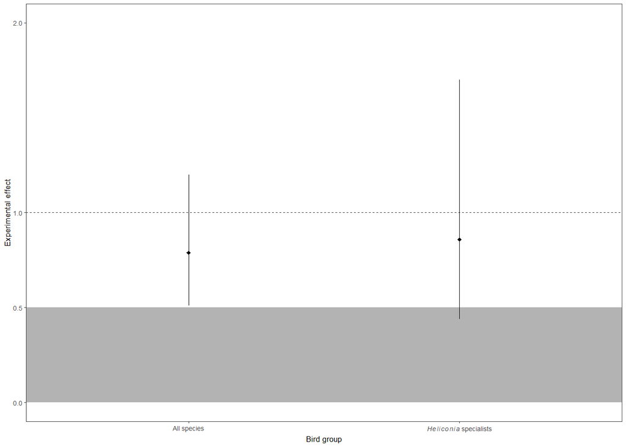

```r
shape_size = shape_size * 1.25

#CAPTURES
capture_contrast_plot <- contrasts_of_contrasts_df %>%
  filter(analysis == "captures" & subanalysis == "captures") %>%
  make_contrast_plot(contrasts_df = ., xvar = "bird_group", xlabel = "Bird group", text_size = size, point_size = shape_size, line_size = line_width) +
    scale_y_continuous(limits = c(0, 2), breaks = c(0, 0.5, 1, 2)) +
    scale_x_discrete(labels = c("All species", expression(italic(Heliconia)~"specialists")))

capture_contrast_plot
```

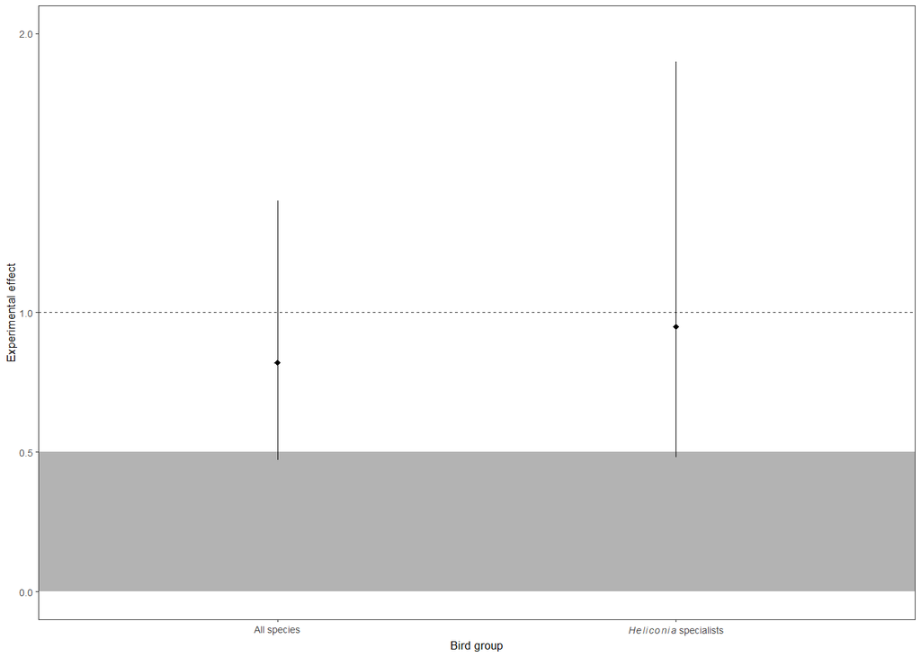

```r
#TELEMETRY
telemetry_contrast_plot <- contrasts_of_contrasts_df %>%
  filter(analysis == "telemetry" & subanalysis == "all_replicates") %>%
  make_contrast_plot(contrasts_df = ., xvar = "bird_group", xlabel = "Bird group", text_size = size, point_size = shape_size, line_size = line_width) +
    scale_y_continuous(limits = c(0, 2), breaks = c(0, 0.5, 1, 2)) +
    scale_x_discrete(labels = c("All species", expression(italic(Heliconia)~"specialists")))

telemetry_contrast_plot
```

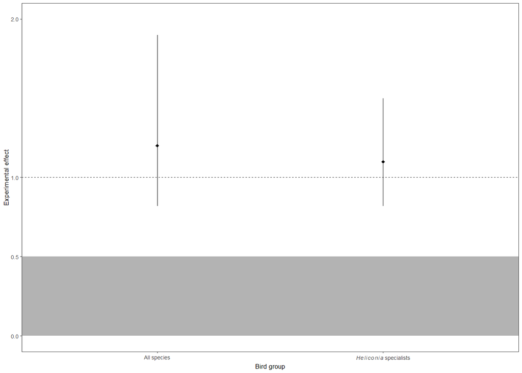

```r
#FLOWER VISITATION: HETO (Heliconia tortuosa)
heto_visits_contrast_plot <- contrasts_of_contrasts_df %>%
  filter(analysis == "camera_HETO" & subanalysis == "all_birds") %>%
  make_contrast_plot(contrasts_df = ., xvar = "bird_group", xlabel = "Bird group", text_size = size, point_size = shape_size, line_size = line_width) +
    scale_y_continuous(limits = c(0, 2), breaks = c(0, 0.5, 1, 2)) +
    scale_x_discrete(labels = c("All species", expression(italic(Heliconia)~"specialists")))

heto_visits_contrast_plot
```

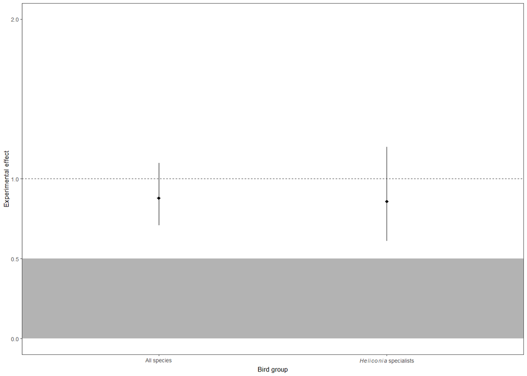

```r
#FLOWER VISITATION: NON-HETO
nonheto_visits_contrast_plot <- contrasts_of_contrasts_df %>%
  filter(analysis == "camera_non-HETO" & subanalysis == "all_birds") %>%
  make_contrast_plot(contrasts_df = ., xvar = "bird_group", xlabel = "Bird group", text_size = size, point_size = shape_size, line_size = line_width)  +
    scale_y_continuous(limits = c(0, 2), breaks = c(0, 0.5, 1, 2)) +
    scale_x_discrete(labels = c("All species", expression(italic(Heliconia)~"specialists")))

nonheto_visits_contrast_plot
```

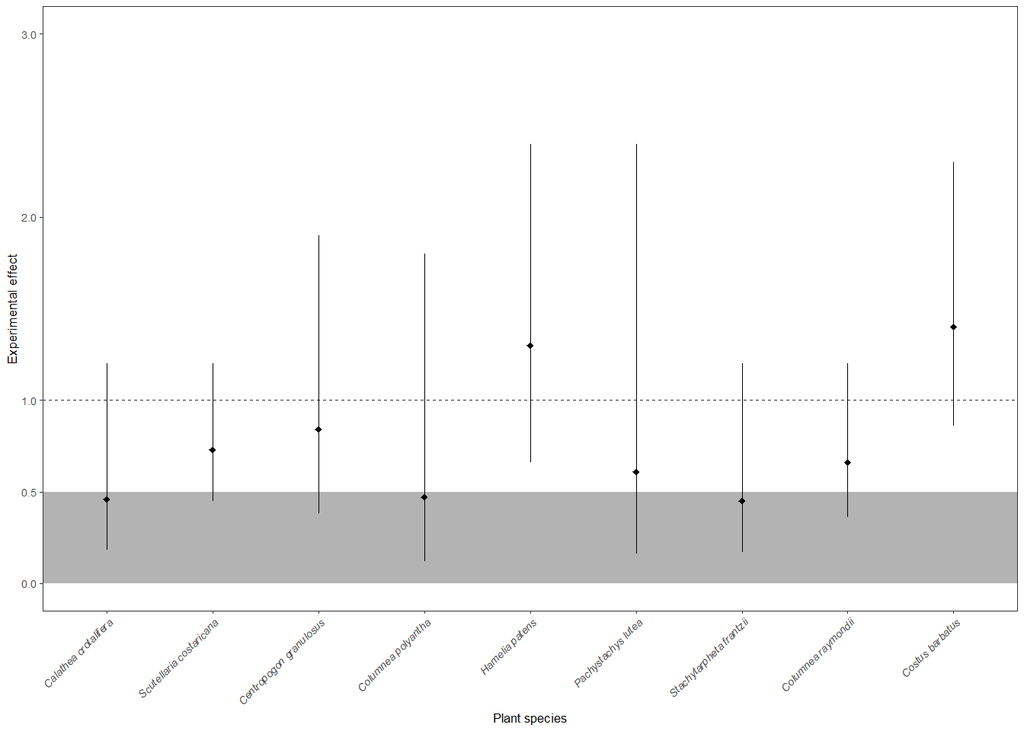

```r
#FLOWER VISITAITON: NON-HETO, INDIVIDUAL PLANT SPECIES
nonheto_contrast_plot <-  contrasts_of_contrasts_df %>%
  filter(analysis == "camera_non-HETO_separate") %>%
  left_join(nonheto_species) %>%
  mutate(plant_scientific_name = forcats::fct_reorder(plant_scientific_name, num_replicates)) %>%
  arrange(desc(num_replicates)) %>%
  make_contrast_plot(contrasts_df = ., xvar = "plant_scientific_name", xlabel = "Plant species", text_size = size, point_size = shape_size, line_size = line_width) +
    scale_y_continuous(limits = c(0, 3), breaks = c(0, 0.5, 1, 2, 3)) +
    coord_cartesian(ylim = c(0, 3), xlim = c(1, 9), clip = "off") +
    theme(axis.text.x = element_text(angle = 45, vjust = 1, hjust = 1, face = "italic"))

nonheto_contrast_plot
```

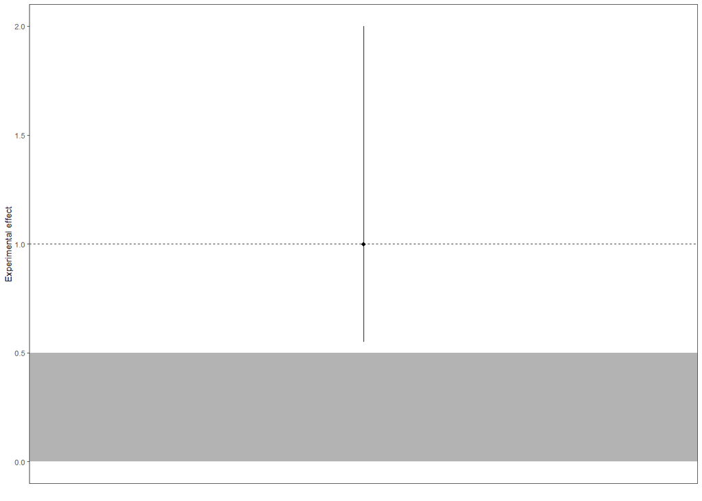

```r
#POLLINATION SUCCESS: HETO (Heliconia tortuosa)
heto_pollination_contrast_plot <- contrasts_of_contrasts_df %>%
  filter(analysis == "pollen_tubes" & subanalysis == "HETO") %>%
  make_contrast_plot(contrasts_df = ., xvar = "subanalysis", xlabel = "", text_size = size, point_size = shape_size, line_size = line_width) +
    theme(axis.text.x = element_blank(), axis.ticks.x = element_blank())

heto_pollination_contrast_plot
```

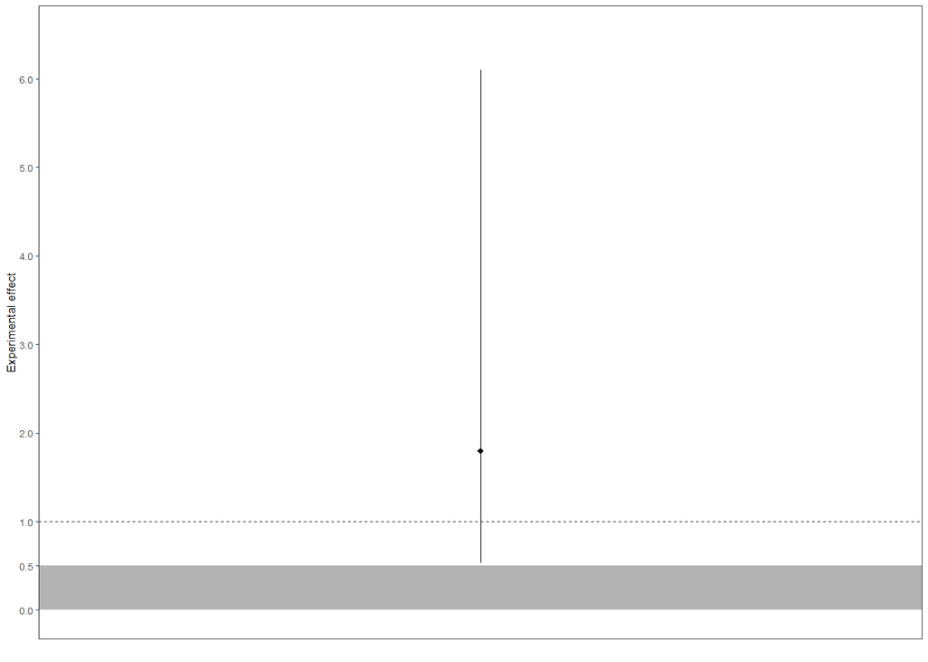

```r
#POLLINATION SUCCESS: HAPA (Hamelia patens)
hapa_pollination_contrast_plot <- contrasts_of_contrasts_df %>%
  filter(analysis == "pollen_tubes" & subanalysis == "HAPA") %>%
  make_contrast_plot(contrasts_df = ., xvar = "subanalysis", xlabel = "", text_size = size, point_size = shape_size, line_size = line_width) +
    theme(axis.text.x = element_blank(), axis.ticks.x = element_blank()) +
    scale_y_continuous(limits = c(0, 6.5), breaks = c(0, 0.5, 1, 2, 3, 4, 5, 6))

hapa_pollination_contrast_plot
```

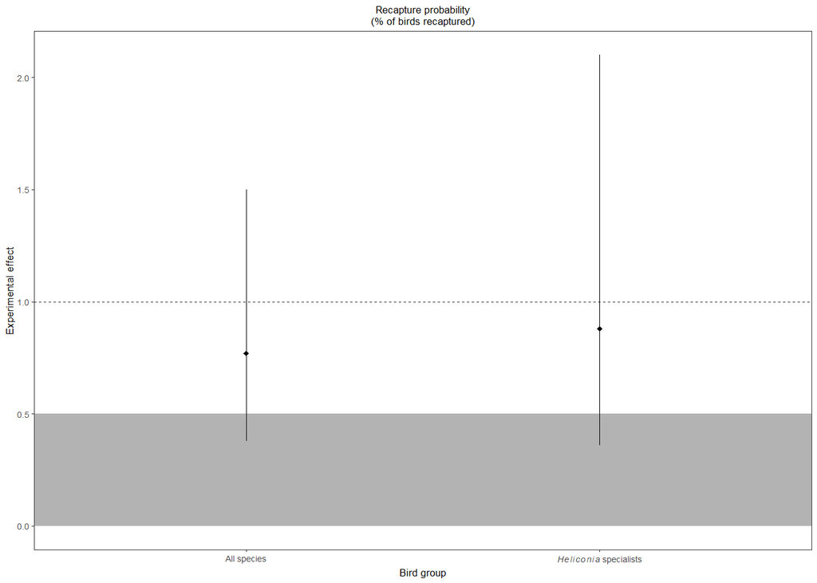

```r
#RECAPTURES
recaps_contrast_plot <- contrasts_of_contrasts_df %>%
  filter(analysis == "captures" & subanalysis == "recaptures") %>%
  make_contrast_plot(contrasts_df = ., xvar = "bird_group", xlabel = "Bird group", text_size = size, point_size = shape_size, line_size = line_width) +
    scale_x_discrete(labels = c("All species", expression(italic(Heliconia)~"specialists"))) +
    labs(title = "Recapture probability\n(% of birds recaptured)") +
    theme(plot.title = element_text(hjust = 0.5, size = size)) #center title

recaps_contrast_plot
```

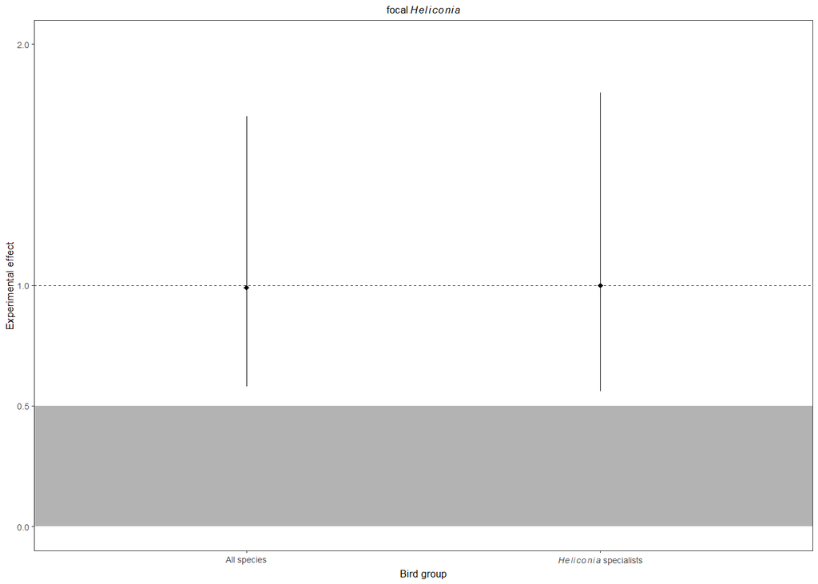

```r
#FLOWER VISITATION: HETO, MARKED BIRDS ONLY
heto_visits_marked_contrast_plot <- contrasts_of_contrasts_df %>%
  filter(analysis == "camera_HETO" & subanalysis == "marked_birds") %>%
  make_contrast_plot(contrasts_df = ., xvar = "bird_group", xlabel = "Bird group", text_size = size, point_size = shape_size, line_size = line_width) +
  scale_x_discrete(labels = c("All species", expression(italic(Heliconia)~"specialists"))) +
  #labs(title = "Flower visitation from marked birds: focal"~italic(Heliconia))
  labs(title = "focal"~italic(Heliconia)) +
  theme(plot.title = element_text(hjust = 0.5, size = size)) + #center title
  scale_y_continuous(limits = c(0, 2), breaks = c(0, 0.5, 1, 2))

heto_visits_marked_contrast_plot
```

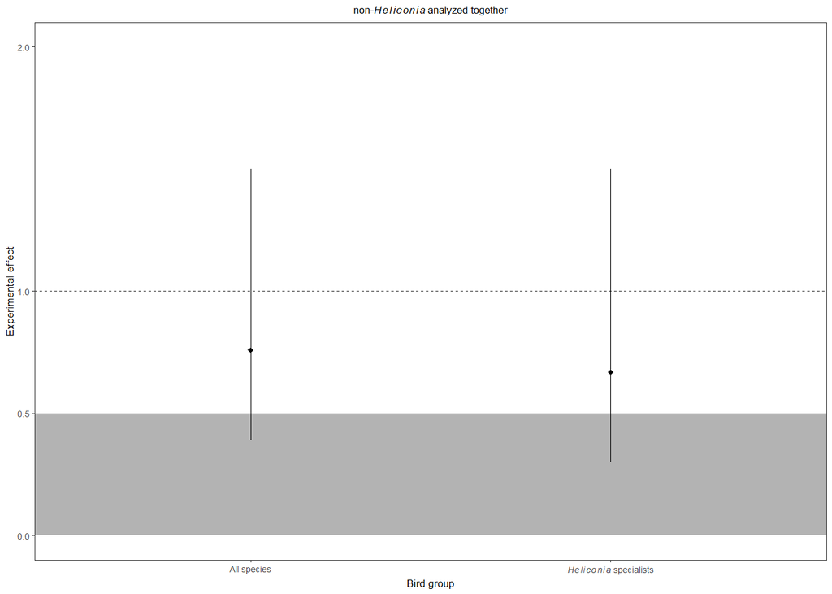

```r
#FLOWER VISITATION: NON-HETO, MARKED BIRDS ONLY
nonheto_visits_marked_contrast_plot <- contrasts_of_contrasts_df %>%
  filter(analysis == "camera_non-HETO" & subanalysis == "marked_birds") %>%
  make_contrast_plot(contrasts_df = ., xvar = "bird_group", xlabel = "Bird group", text_size = size, point_size = shape_size, line_size = line_width) +
  scale_x_discrete(labels = c("All species", expression(italic(Heliconia)~"specialists"))) +
  #labs(title = "Flower visitation from marked birds: non-"*italic(Heliconia)~"species ("*italic(N)~"= 17)")
  labs(title = "non-"*italic(Heliconia)~"analyzed together") +
  theme(plot.title = element_text(hjust = 0.5, size = size)) + #center title
  scale_y_continuous(limits = c(0, 2), breaks = c(0, 0.5, 1, 2))

nonheto_visits_marked_contrast_plot
```

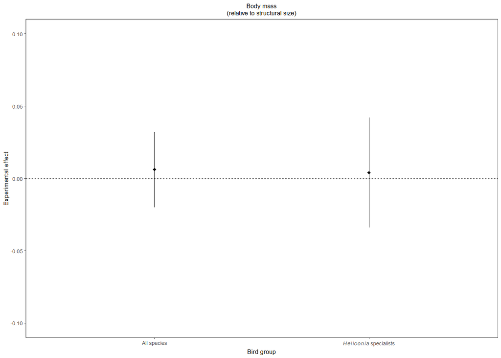

```r
#BODY MASS
body_mass_contrast_plot <- contrasts_of_contrasts_df %>%
  filter(analysis == "body_mass") %>%
  make_contrast_plot(contrasts_df = ., xvar = "bird_group", xlabel = "Bird group", text_size = size, point_size = shape_size, line_size = line_width) +
    scale_y_continuous(limits = c(-0.10, 0.10)) +
    scale_x_discrete(labels = c("All species", expression(italic(Heliconia)~"specialists"))) +
    labs(title = "Body mass\n(relative to structural size)") +
    theme(plot.title = element_text(hjust = 0.5, size = size)) #center title

body_mass_contrast_plot
```

**Organize figures into panel plots for publication**